```python
import pandas as pd
import numpy as np
import matplotlib.pyplot as plt
import seaborn as sns
from matplotlib.lines import Line2D
from matplotlib.cm import get_cmap
```

```python
df = pd.read_csv("../data/heart.csv")
```

# Questions to answer:

## What are the reasons for heart disease

## Who are the people most vulnerable to it

# Data Schema

#### -age

#### -sex (1 = male; 0 = female)

#### -chest pain type (4 values)

#### -resting blood pressure

#### -serum cholesterol in mg/dl

#### -fasting blood sugar > 120 mg/dl

#### -resting electrocardiographic results (values 0,1,2)

#### -maximum heart rate achieved

#### -exercise induced angina

#### -oldpeak = ST depression induced by exercise relative to rest

#### -the slope of the peak exercise ST segment

#### -number of major vessels (0-3) colored by fluoroscopy

#### -thal: 1 = normal; 2 = fixed defect; 3 = reversable defec,

#### -target: presence of heart disease

# Main problems with the data:

### Small sample

### Skewed data (we don't have enough samples for every gender at every age, same can be said for almost every feature column)

### Majority of female samples are positive

### Very heavy bias, since the data is taken when the person is hospitalized

```python
labels_dict = {
    "age": "age",
    "sex": "sex",
    "cp": "chest pain type",
    "trestbps": "resting blood pressure (mm/Hg)",
    "chol": "serum cholesterol (mg/dl)",
    "fbs": "fasting blood sugar (> 120 mg/dl)",
    "restecg": "resting electrocardiographic results",
    "thalach": "maximum heart rate achieved",
    "exang": "exercise induced angina",
    "oldpeak": "ST depression induced by exercise relative to rest",
    "slope": "slope of peak exercise ST segment",
    "ca": "nb of major vessels colored by fluoroscopy",
    "thal": "heart rate type?",
    "target": "heart disease"
}
```

```python
df.head()
```

|  | age | sex | cp | trestbps | chol | fbs | restecg | thalach | exang | oldpeak | slope | ca | thal | target |
| --- | --- | --- | --- | --- | --- | --- | --- | --- | --- | --- | --- | --- | --- | --- |
| 0 | 63 | 1 | 3 | 145 | 233 | 1 | 0 | 150 | 0 | 2.3 | 0 | 0 | 1 | 1 |
| 1 | 37 | 1 | 2 | 130 | 250 | 0 | 1 | 187 | 0 | 3.5 | 0 | 0 | 2 | 1 |
| 2 | 41 | 0 | 1 | 130 | 204 | 0 | 0 | 172 | 0 | 1.4 | 2 | 0 | 2 | 1 |
| 3 | 56 | 1 | 1 | 120 | 236 | 0 | 1 | 178 | 0 | 0.8 | 2 | 0 | 2 | 1 |
| 4 | 57 | 0 | 0 | 120 | 354 | 0 | 1 | 163 | 1 | 0.6 | 2 | 0 | 2 | 1 |

```python
df.describe()
```

|  | age | sex | cp | trestbps | chol | fbs | restecg | thalach | exang | oldpeak | slope | ca | thal | target |
| --- | --- | --- | --- | --- | --- | --- | --- | --- | --- | --- | --- | --- | --- | --- |
| count | 303.000000 | 303.000000 | 303.000000 | 303.000000 | 303.000000 | 303.000000 | 303.000000 | 303.000000 | 303.000000 | 303.000000 | 303.000000 | 303.000000 | 303.000000 | 303.000000 |
| mean | 54.366337 | 0.683168 | 0.966997 | 131.623762 | 246.264026 | 0.148515 | 0.528053 | 149.646865 | 0.326733 | 1.039604 | 1.399340 | 0.729373 | 2.313531 | 0.544554 |
| std | 9.082101 | 0.466011 | 1.032052 | 17.538143 | 51.830751 | 0.356198 | 0.525860 | 22.905161 | 0.469794 | 1.161075 | 0.616226 | 1.022606 | 0.612277 | 0.498835 |
| min | 29.000000 | 0.000000 | 0.000000 | 94.000000 | 126.000000 | 0.000000 | 0.000000 | 71.000000 | 0.000000 | 0.000000 | 0.000000 | 0.000000 | 0.000000 | 0.000000 |
| 25% | 47.500000 | 0.000000 | 0.000000 | 120.000000 | 211.000000 | 0.000000 | 0.000000 | 133.500000 | 0.000000 | 0.000000 | 1.000000 | 0.000000 | 2.000000 | 0.000000 |
| 50% | 55.000000 | 1.000000 | 1.000000 | 130.000000 | 240.000000 | 0.000000 | 1.000000 | 153.000000 | 0.000000 | 0.800000 | 1.000000 | 0.000000 | 2.000000 | 1.000000 |
| 75% | 61.000000 | 1.000000 | 2.000000 | 140.000000 | 274.500000 | 0.000000 | 1.000000 | 166.000000 | 1.000000 | 1.600000 | 2.000000 | 1.000000 | 3.000000 | 1.000000 |
| max | 77.000000 | 1.000000 | 3.000000 | 200.000000 | 564.000000 | 1.000000 | 2.000000 | 202.000000 | 1.000000 | 6.200000 | 2.000000 | 4.000000 | 3.000000 | 1.000000 |

```python
df.isnull().values.any()
```

```
False
```

```python
df["thal"].value_counts()
```

```
2    166
3    117
1     18
0      2
Name: thal, dtype: int64
```

```python
max_female = df["sex"].value_counts()[0]
max_male = df["sex"].value_counts()[1]
```

## Visualizing the data

```python
sns.set_theme()

def add_title(x, hue, ax=None, title=None):
    if title:
        if ax:
            ax.set_title(title)
        else:
            plt.title(title)
    else:
        if ax:
            ax.set_title(rf"Distribution of {x} $\backsim$ {hue}")
        else:
            plt.title(rf"Distribution of {x} $\backsim$ {hue}")


def plot_hist(data, x, hue=None, stat="count", ax=None, xlabel=None, title=None):
    sns.histplot(data=data, x=x, hue=hue, stat=stat, multiple="stack", ax=ax)
    if ax:
        ax.set_xlabel([xlabel, x][xlabel is None])
        ax.set_ylabel(["occurences", "frequency"][stat != "count"])
        add_title(x, hue, ax, title)
    else:
        plt.xlabel([xlabel, x][xlabel is None])
        plt.ylabel(["occurences", "frequency"][stat != "count"])
        add_title(x, hue, ax, title)
        plt.show();
```

### sex

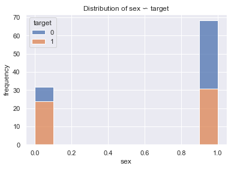

```python
plot_hist(df, "sex", "target", stat="percent")
```

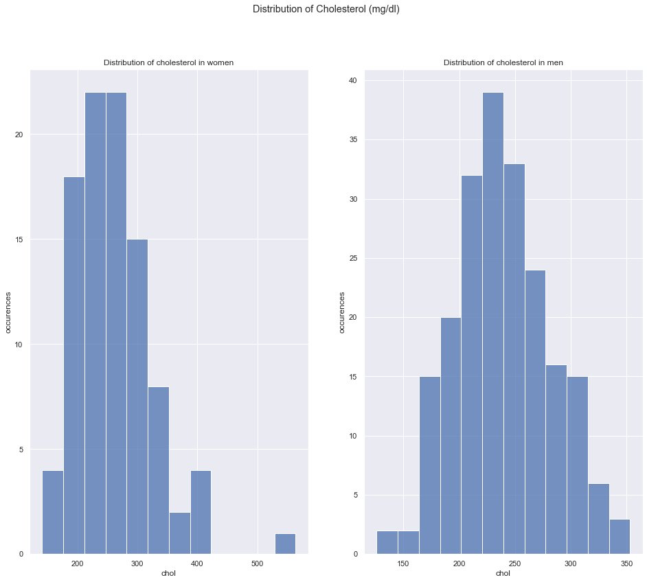

```python
fig, axes = plt.subplots(1, 2)
fig.figure.set_figwidth(16)
fig.figure.set_figheight(13)
plot_hist(df[df["sex"] == 0], x="chol", hue=None, ax=axes[0], title="Distribution of cholesterol in women")
plot_hist(df[df["sex"] == 1], x="chol", hue=None, ax=axes[1], title="Distribution of cholesterol in men")
fig.suptitle("Distribution of Cholesterol (mg/dl)");
```

## The 500+ cholesterole looks like a severe outlier (if not data typo?). A google research tells us that it is possible though.

### age

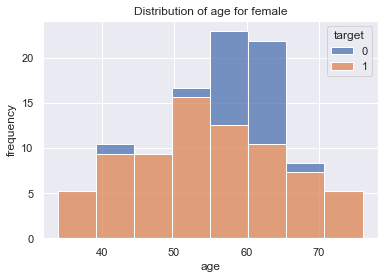

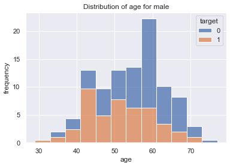

```python
plot_hist(data=df[df["sex"] == 0], x="age", hue="target", stat="percent", title="Distribution of age for female")
plot_hist(data=df[df["sex"] == 1], x="age", hue="target", stat="percent", title="Distribution of age for male")
```

## The female samples seem to be older than the males

```python
cols = list(df.columns)
cols.pop(cols.index("age"))
cols.pop(cols.index("sex"))
cols.pop(cols.index("target"));
```

```python
# Let's bucketize the age for an easier visualization
bins = [25, 40, 55, 70, 85]
df['binned_age'] = pd.cut(df['age'], bins)
```

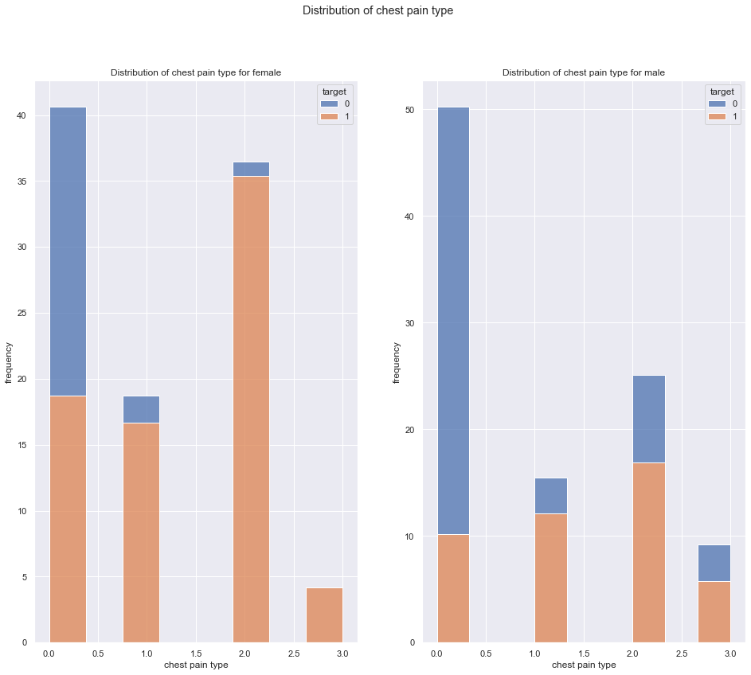

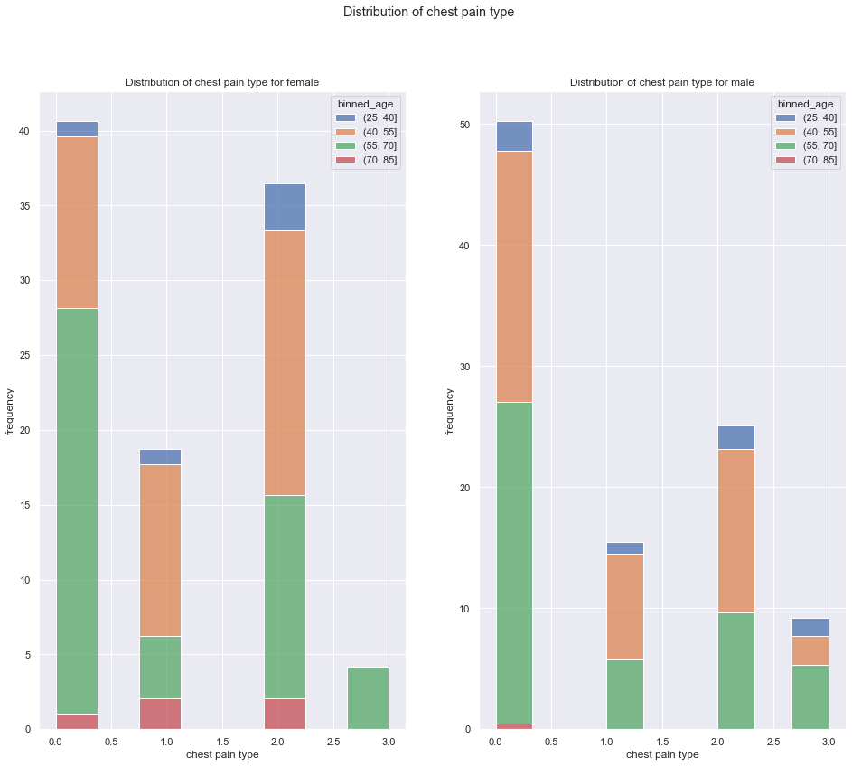

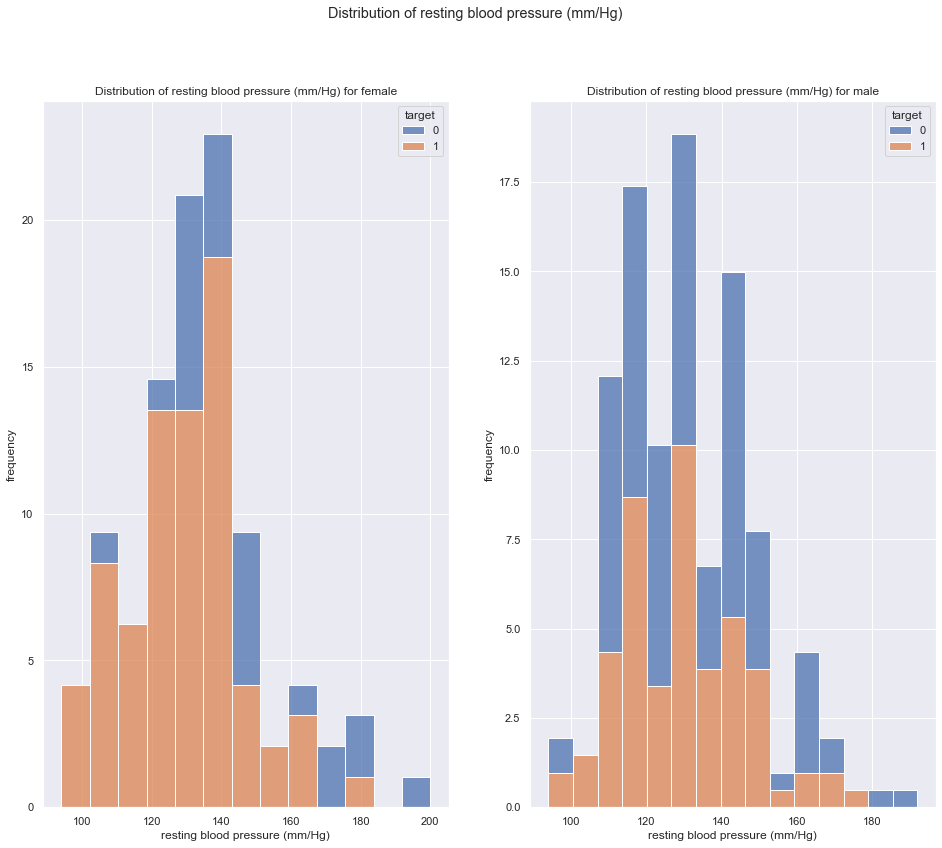

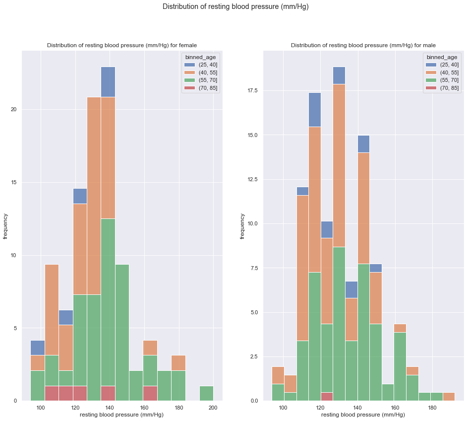

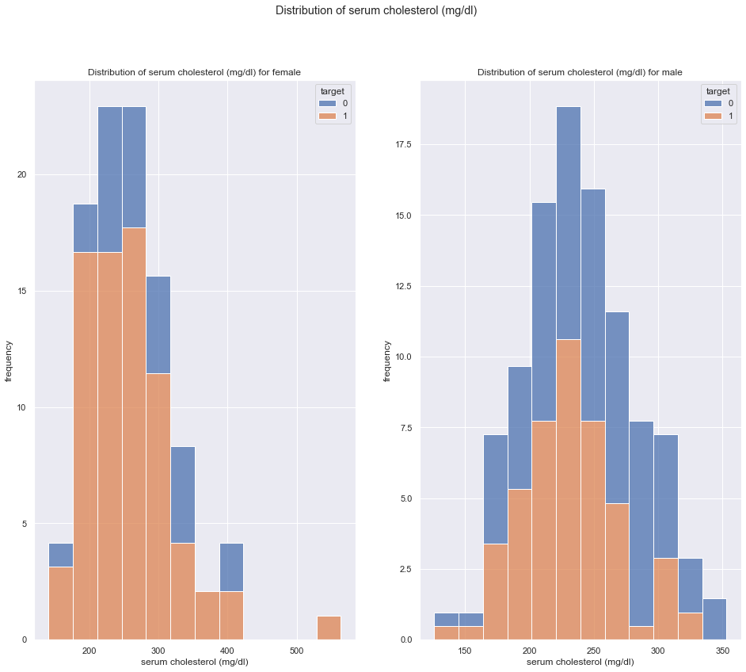

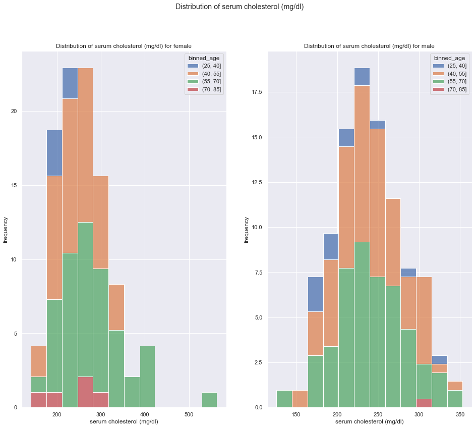

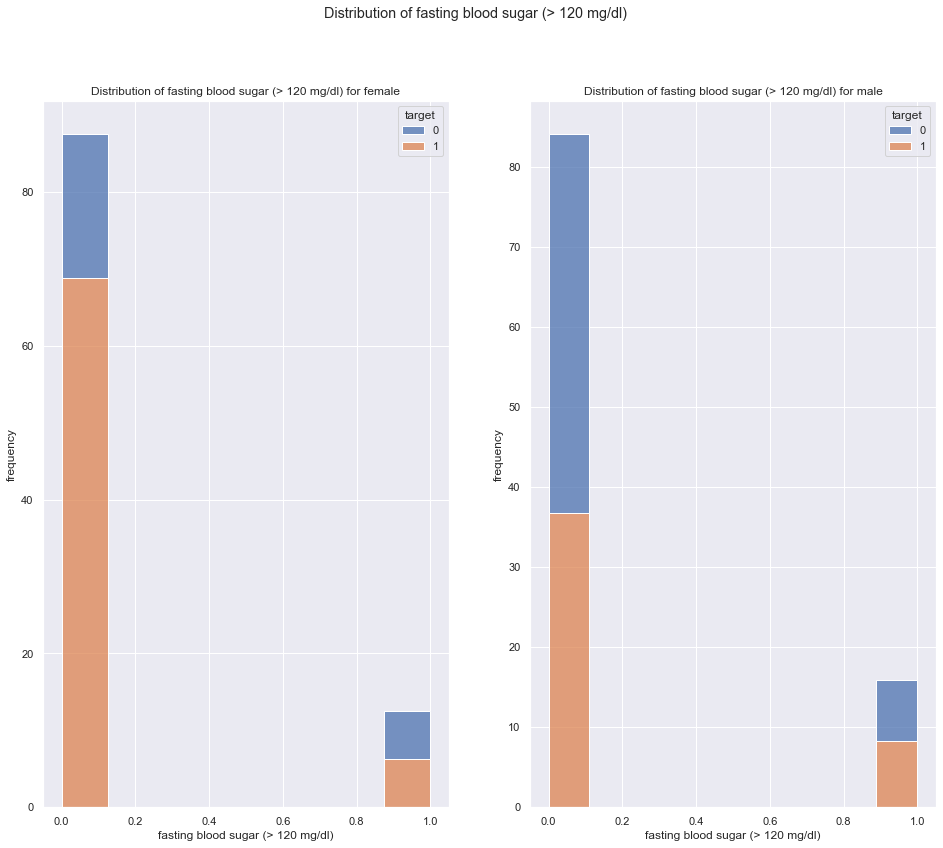

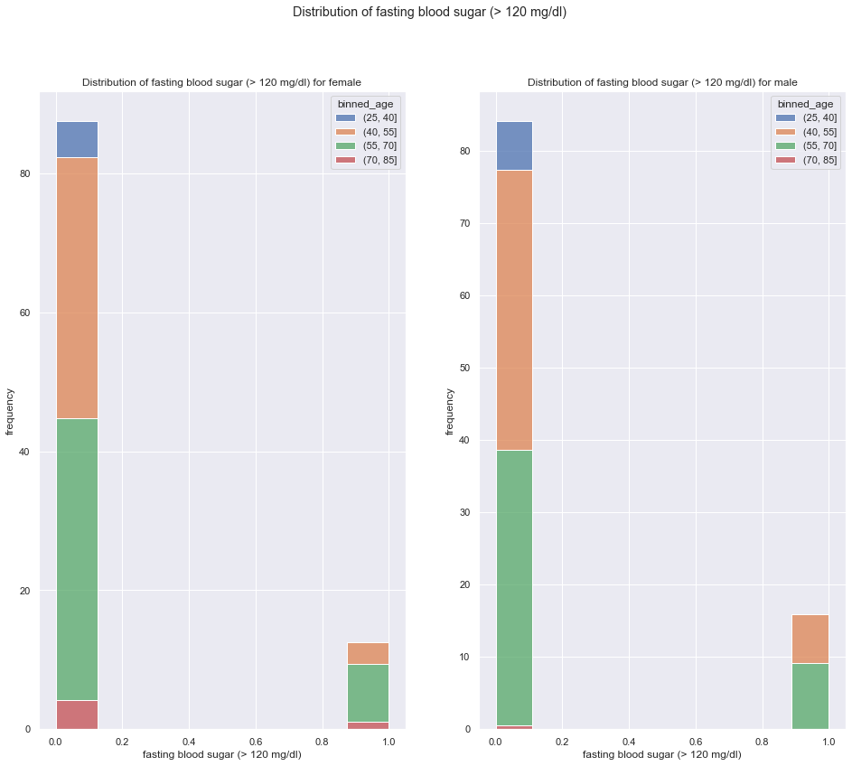

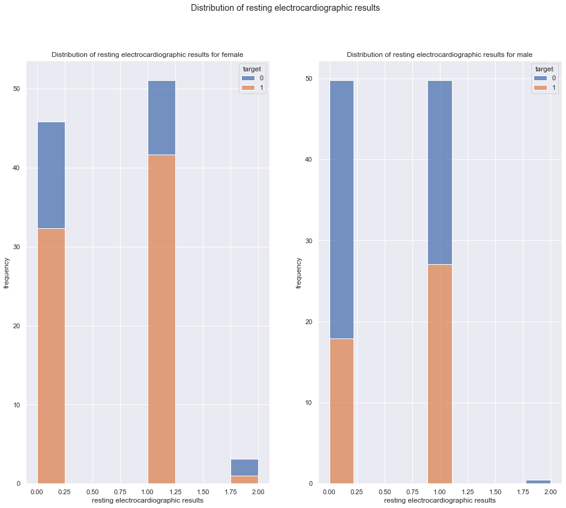

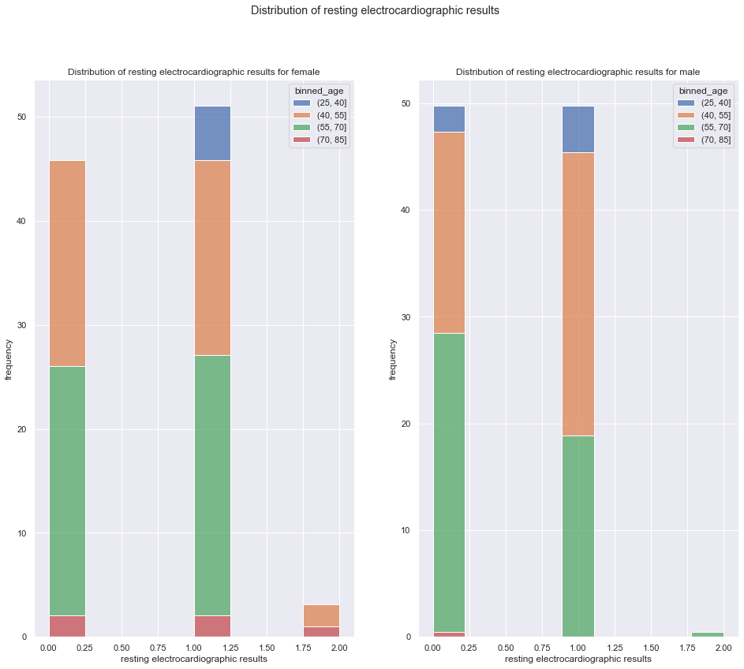

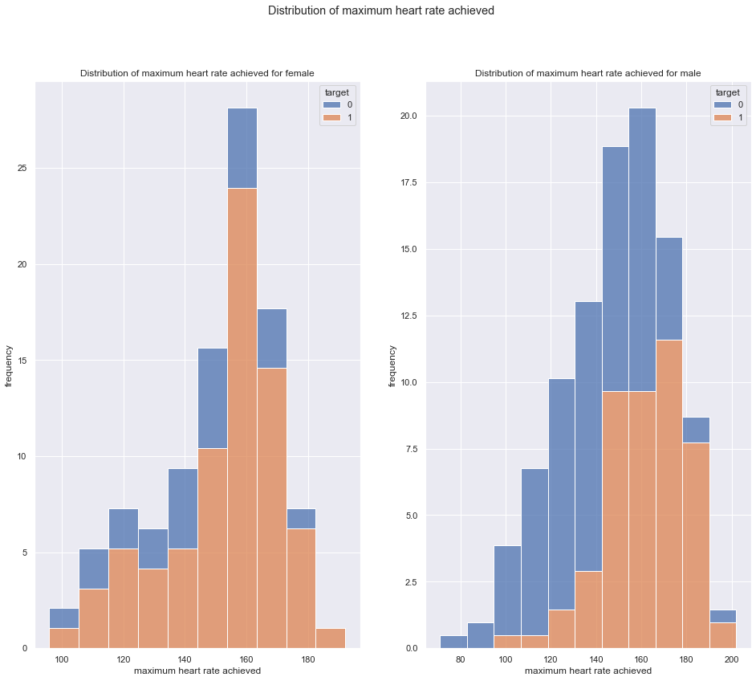

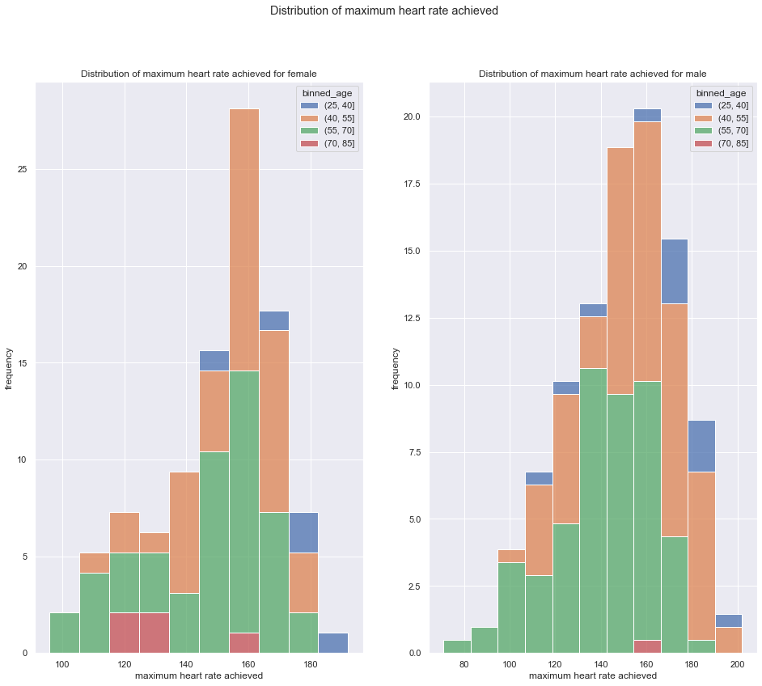

[10 more figures not shown]

```python
import shutil

# Terminal size. Used later to delimit and separate the different plots
terminal_width, terminal_height = shutil.get_terminal_size((80, 20))


# For every column, we are going to visualize it per sex, and have the target and age as a hue
# to see how everything plays together.
for col in cols:

    # TARGET
    fig, axes = plt.subplots(1, 2)
    fig.figure.set_figwidth(16)
    fig.figure.set_figheight(13)
    fig.suptitle(f"Distribution of {labels_dict[col]}")
    plot_hist(data=df[df["sex"] == 0], x=col, hue="target", stat="percent", xlabel=labels_dict[col],
              title=f"Distribution of {labels_dict[col]} for female", ax=axes[0])

    plot_hist(data=df[df["sex"] == 1], x=col, hue="target", stat="percent", xlabel=labels_dict[col],
              title=f"Distribution of {labels_dict[col]} for male", ax=axes[1])
    plt.show();

    # AGE
    fig, axes = plt.subplots(1, 2)
    fig.figure.set_figwidth(16)
    fig.figure.set_figheight(13)
    fig.suptitle(f"Distribution of {labels_dict[col]}")
    plot_hist(data=df[df["sex"] == 0], x=col, hue="binned_age", stat="percent", xlabel=labels_dict[col],
              title=f"Distribution of {labels_dict[col]} for female", ax=axes[0])

    plot_hist(data=df[df["sex"] == 1], x=col, hue="binned_age", stat="percent", xlabel=labels_dict[col],
              title=f"Distribution of {labels_dict[col]} for male", ax=axes[1])
    plt.show()

    # Plot delimiter
    print("-" * terminal_width)
```

## There seems to be a correlation between chest pain and heart disease.

## Maximum heart rate in male has a correlation with heart disease. Hard to say anything for women.

# Correlation for slope when it is high, otherwise not a lot

# 0 vessels colored by fluoroscopy seems to be a strong indicator as well.

## Checking correlations more rigorously.

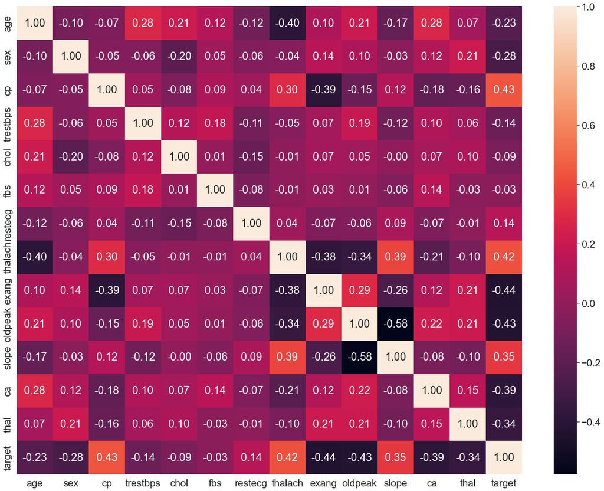

```python
plt.figure(figsize=(25, 19))
sns.set(font_scale=2)

f = sns.heatmap(df.corr(), annot=True, fmt=".2f")
```

## Visualizing outliers

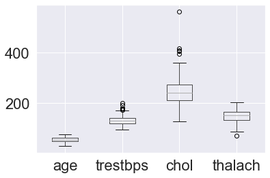

```python
numerical_cols = ["age", "trestbps", "chol", "thalach"]

df[numerical_cols].boxplot()
```

### Only outlier that really stands out is the >500 mg/dl cholesterol, which according to google is possible

## Using PCA to reduce dimensions to the most essential ones

### /!\ This actually doesn't work. It isn't a matter of normalization, but the data types are mixed between categorical and numerical /!\

##### Additional note: the PCA should be trained on the training data as well, and not on all data. This is just an exploratory step to see if everything works.

### Factor Analysis for Mixed Data would work better.

```python
from sklearn.decomposition import PCA

features = df[[x for x in list(df.columns) if x not in ["target", "binned_age"]]]
pca = PCA(n_components=3)

pca_reduced_features = pca.fit(features)


# Extracting original feature importance
components_influence_ratios = []

for i in range(3):
    components = list(map(lambda x: abs(x), pca_reduced_features.components_[i]))

    total = sum(components)

    ratios = list(map(lambda x: (x / total) * pca_reduced_features.explained_variance_ratio_[i], components))
    components_influence_ratios.append(ratios)

components_influence_ratios = np.array(components_influence_ratios)
```

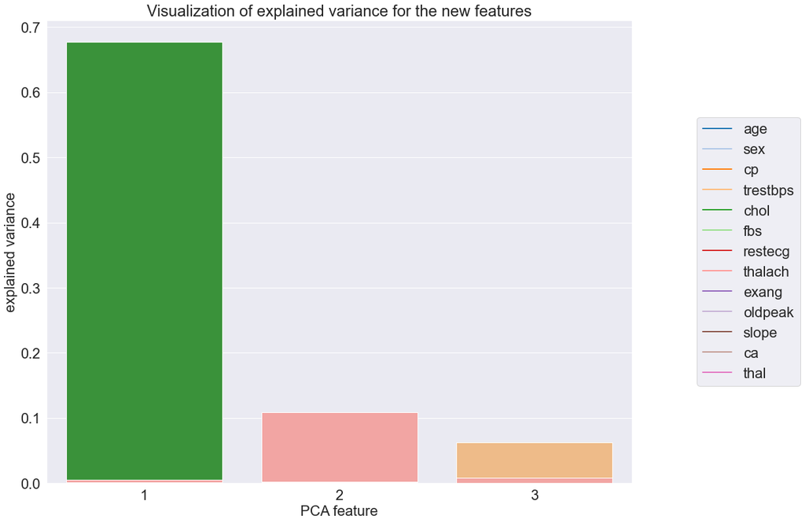

```python
plt.figure(figsize=(16, 13))
plt.ylabel("explained variance", fontsize=22)
plt.xlabel("PCA feature", fontsize=22)
plt.title("Visualization of explained variance for the new features")


legend_lines = []
features_names = list(features.columns)
for i in range(len(pca_reduced_features.components_[0])):
    color = get_cmap("tab20")(i)
    sns.barplot(x = [1, 2, 3], y = components_influence_ratios[:, i], color=color)

    legend_lines.append(Line2D([0], [0], color=color, lw=2))

plt.legend(legend_lines, features_names, loc="right", bbox_to_anchor=(1.3, 0.5), fontsize=22)
```

```python
famd_df
```

|  | age | sex | cp | trestbps | chol | fbs | restecg | thalach | exang | oldpeak | slope | ca | thal |
| --- | --- | --- | --- | --- | --- | --- | --- | --- | --- | --- | --- | --- | --- |
| 0 | 63 | 1 | 3 | 145 | 233 | 1 | 0 | 150 | 0 | 2.3 | 0 | 0 | 1 |
| 1 | 37 | 1 | 2 | 130 | 250 | 0 | 1 | 187 | 0 | 3.5 | 0 | 0 | 2 |
| 2 | 41 | 0 | 1 | 130 | 204 | 0 | 0 | 172 | 0 | 1.4 | 2 | 0 | 2 |
| 3 | 56 | 1 | 1 | 120 | 236 | 0 | 1 | 178 | 0 | 0.8 | 2 | 0 | 2 |
| 4 | 57 | 0 | 0 | 120 | 354 | 0 | 1 | 163 | 1 | 0.6 | 2 | 0 | 2 |
| ... | ... | ... | ... | ... | ... | ... | ... | ... | ... | ... | ... | ... | ... |
| 298 | 57 | 0 | 0 | 140 | 241 | 0 | 1 | 123 | 1 | 0.2 | 1 | 0 | 3 |
| 299 | 45 | 1 | 3 | 110 | 264 | 0 | 1 | 132 | 0 | 1.2 | 1 | 0 | 3 |
| 300 | 68 | 1 | 0 | 144 | 193 | 1 | 1 | 141 | 0 | 3.4 | 1 | 2 | 3 |
| 301 | 57 | 1 | 0 | 130 | 131 | 0 | 1 | 115 | 1 | 1.2 | 1 | 1 | 3 |
| 302 | 57 | 0 | 1 | 130 | 236 | 0 | 0 | 174 | 0 | 0.0 | 1 | 1 | 2 |

303 rows × 13 columns

```python
import prince
famd = prince.FAMD(
                   n_components=13,
                   n_iter=10,
                   copy=True,
                   check_input=True,
                   engine='auto',
                   random_state=42,
                  )
famd = famd.fit(famd_df)  # , rescale_with_mean=True, rescale_width_std=True)
```

```python
sum(famd.explained_inertia_)
```

```
0.822114154312918
```

```python
sum(famd.explained_inertia_[:5])
```

```
0.4852300220438477
```

### The github repository tested took some time to be understand, only to find out after implementing everything that the very final step has a bug and hence everything can't be used :))))). 2 important things though, we see that the maximum amount of variance that can be explained is around 82% which seems to be what we are getting with our ML models later on, and 5 feature columns seem to be explaining half of it, which is adequate with what we are getting from random forst. This doesn't mean it is the only possibility, since XGBoost might be yielding a sparse matrix.

## Machine learning for prediction. The role of the prediction will be to better understand the data and the important factors leading to heart disease. Since the data is heavily biased by the hospitalization, it isn't certain that we have at hands causality.

### Splitting the data

```python
# We will handle class imbalance by giving a weight instead of resampling
from sklearn.model_selection import train_test_split

features_list = [x for x in list(df.columns) if x not in ["target", "binned_age"]]
X = df[features_list].values
y = df["target"].values

# Data splitting
X_train, X_test, y_train, y_test = train_test_split(X, y, test_size=0.33, random_state=42)
```

```python
true_count = len(y_train[y_train == 1])
neg_count = len(y_train[y_train == 0])

true_weight = true_count / (true_count + neg_count)
neg_weight = neg_count / (true_count + neg_count)

weight_dict = {0: neg_weight, 1: true_weight}
weight_array = np.array([1]*y_train.shape[0], dtype="float")  # dtype is very important, otherwise it gets rounded to 0!
for idx, val in enumerate(y_train):
    if val == 1:
        weight_array[idx] = true_weight
    else:
        weight_array[idx] = neg_weight
```

```python
# Model training and metrics
from sklearn.metrics import confusion_matrix
from sklearn.metrics import accuracy_score

def train_and_test_model(model, model_name, weight_array=None, pca_X_train=None, pca_X_test=None):

    X_training = [pca_X_train, X_train][pca_X_train is None]
    X_testing = [pca_X_test, X_test][pca_X_test is None]

    if weight_array is not None:
        model.fit(X_training, y_train, sample_weight=weight_array)
    else:
        model.fit(X_training, y_train)
    y_pred = model.predict(X_testing)
    conf_mat = confusion_matrix(y_test, y_pred)
    sns.heatmap(conf_mat, annot=True, fmt="d")
    plt.xlabel("True label")
    plt.ylabel("Predicted label")
    plt.title(f"{model_name} - Classification confusion matrix")
    plt.show()

    # Accuracy
    # We only focus on accuracy since both false pos and false neg are important to us to understand the data.
    print(f"Accuracy: {(accuracy_score(y_test, y_pred) * 100):.2f} %")

    # Feature importance. We cannot access it for SVMs sadly.
    feature_importance_dict = {}
    for label, importance in zip(features_list, model.feature_importances_):
        feature_importance_dict[label] = round(importance * 100) / 100
    print(f"Feature importance: {feature_importance_dict}")
```

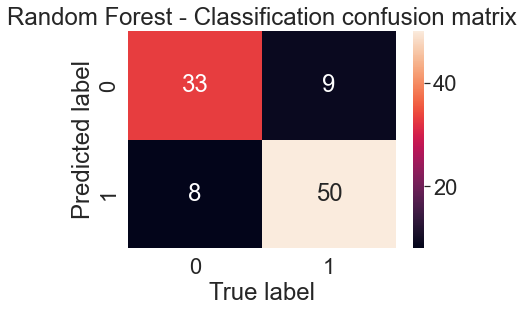

```
Accuracy: 83.00 %
Feature importance: {'age': 0.08, 'sex': 0.03, 'cp': 0.13, 'trestbps': 0.07, 'chol': 0.07, 'fbs': 0.01, 'restecg': 0.02, 'thalach': 0.1, 'exang': 0.07, 'oldpeak': 0.12, 'slope': 0.05, 'ca': 0.16, 'thal': 0.09}
```

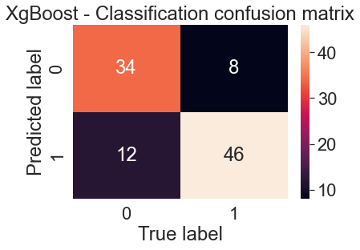

```
Accuracy: 80.00 %
Feature importance: {'age': 0.04, 'sex': 0.01, 'cp': 0.21, 'trestbps': 0.04, 'chol': 0.03, 'fbs': 0.01, 'restecg': 0.01, 'thalach': 0.05, 'exang': 0.05, 'oldpeak': 0.11, 'slope': 0.04, 'ca': 0.24, 'thal': 0.14}
```

```python
from sklearn.ensemble import RandomForestClassifier,  GradientBoostingClassifier

model = RandomForestClassifier(class_weight=weight_dict)
train_and_test_model(model, "Random Forest")

model = GradientBoostingClassifier()
train_and_test_model(model, "XgBoost", weight_array)
```

### The fact that we get different sets of features isn't a problem, because features are correlated between each others. This means that while we didn't get cholesterole as a high priority feature from the models, due to the correlation it has with other features, we are able to retrieve the information incoded in the cholesterole column

# Conclusion

### sadly an L1 penalty would have been really useful here to force a better set selection from random forest, but only an L2 one is implemented which doesn't lead to a sparse matrix.

## On top of these explanations, we have trained some models which could be helpful to predict the urgency of care for a patient at hospitalization time. With hyperparameter tuning we may be able to reach the 85% accuracy rate, but it is unsure if it would make sense since - according to FAMD - the data only explains ~82% of variance.

## However, if it were to be used, it should be retrained to have recall in mind, in order to give false negatives more importance than false positives.